# IE360 PROJECT REPORT

## Group 15

Ufuk Üstündağ

Bekir Keldal

Çınar Eriş

Utku Giden

## 1) INTRODUCTION

Trendyol is an online shopping company which brings buyers and sellers together at a platform. In this project, 8 products of the company were examined on the purpose of forecasting their sales volumes for each day. The necessary data for the task was provided by the company continuously according to the results of the previous day. Therefore, the prediction on the sales were made via two day ahead forecasts.

The provided data included average price of the sold products, number of items sold, number of visits, the addition count of the product to favorites and basket, number of items sold in that category and brand’s particular category, number of visits of the category, and overall visits on the company’s website. All these 9 statistics were available for each day and product.

The 8 products sales of, which were forecasted through a one month period, included a pair of tights for women which is expected to decrease its sales towards summer, a pair of wireless airphones and wet napkins for babies which are highly sensitive to their prices, an electronic tooth brush with a high variation of sales amount, a facial cleansing gel and a hoover with relatively lower variations, and finally a coat and a pair of bikini which get almost no sales (it was thought that the bikini may have tended to increase its sales towards summer though).

The predictions of sales volumes were performed via statistical analysis and forecasting methods. The methods that were used can be listed as follows: Naive forecast (to create a benchmark), moving average, ets model (error – trend – seasonal), arima model (autoregressive integrated moving average), and dynamic regression. The details of the forecasting methods are extended below at “related literature”.

Through the project period, sales forecasts for the following day were submitted continuously and were evaluated according to WMAPE (Weighted Mean Absolute Percentage Error) value, which gives higher weight to the products with more sales volume.

## 2) RELATED LITERATURE

A time series is a series of data points ordered in time. Various analyses are made on time series in many fields, especially financial and economic applications. In this project, the purpose of use of time series is to be able to make meaningful inferences about the subject and to make predictions about the future sales.

Making predictions about future outcomes requires detailed statistical analysis of the past data. For this purpose several forecasting methods are used with time series.

Naive forecast is the simples forecasting method which uses the last observed data as the prediction of the next without any adjustments. Naive forecast usually serves as a benchmark and its outcomes are compared with outcomes of more sophisticated forecasting methods to estimate how much value is added by the use of other methods.

Moving average is another simple forecast technique to analyze data points by taking averages of different subsets of the data. The usual purpose of using moving average on time series is to identify whether the analyzed data follows a trend which shows the general tendency of the data during a period of time.

Another forecasting method is exponential smoothing. This method combines error, trend and seasonal components of the time series data additively, multiplicatively or leaves these components out of the model which is referred as ETS model.

The autoregressive integrated moving average model (ARIMA) is one of the fundamental time series model that consists of 3 main components first of which is the autoregressive component which indicates the relation between the current dependent variable at lagged time periods. The second component is the integrated component which implies the use of data conversion by subtracting the historical values of the variable from its current values. Finally, the moving average component refers to the dependency between the dependent variable and the lagged forecast errors.

Dynamic regression models are models that involve not only the past data of time series future of which is to be forecasted but also the historic data of other related time series to be used as regressors and add more related information to the forecast of the main variable.

To pick the best method among these, several performance measures are available:

## 3) APPROACH

The first step while tackling the task was to clean the data and making necessary manipulations to be able to run the planned analyses. For this purpose, the portion of the data which included the dates before January 23th were cut off since some the values were entered as -1, meaning that those values were missing and could give rise to misleading results. Afterwards, in order to handle more easily, the data was divided into 8 portions. Therefore, 8 different time series were analyzed separately, one for each product.

In order to carry a healthy analysis, it was crucial to handle the outliers since these extreme values could cause deceptive outcomes. To detect the outliers, the past data was plotted and extreme values were selected, special event days which could have a huge effect on sales were also picked such as black Friday and valentine’s day. In addition, through the analysis period, the products were closely tracked from the website, discount days and placement of products on the website were emphasized. The values selected as outliers were placed with the average of the last seven data before that particular value.

Before applying the forecast methods to the 8 time series it was checked whether the sales data included seasonality. The plots were observed visually and autocorrelation function was run for each, however, no seasonality was detected, therefore decomposition technique ( a method to obtain trend, seasonality, and error manually) was not applied.

Afterwards, all different forecast methods were applied to each sales series for all products. By cross validation technique, the available data was divided into a train and a test data. The test data was predicted and according to the performance measures (MSE, MAPE, AICc) the best forecast method for the sales of each of 8 items was decided separately. Also, the residuals were checked to validate that they follow a white noise path. Cross validation was performed again, as new data was obtained through the project period and each day the best forecasting techniques were decided again.

In order to apply dynamic regression, the most significant variables were elected via linear regression model. Multicollinearity was avoided. The chosen regressors were also predicted since their future values would be unknown through the project period. All forecast methods except dynamic regression were used to obtain forecast values of the regressors of dynamic regression. In a similar manner, cross validation was used and the best forecast method for each regressor were elected separately via performance measures.

However, the forecast values achieved by the models weren’t the only determinant for the submitted forecast values. As experience about the sales of the products was gained through the project period, it is noticed that some other clues are included about the sales volumes in the website of the company such as the time passed since last stockout, the remaining models of the product, and the placement of the products at the website. According to the observations of such clues, the forecast values were adjusted before making the submissions.

## 4) RESULTS

As stated above, necessary cleaning and manipulation operations were carried on the data. Dates with -1 values were removed, 8 different time series were created for each product, and outliers were smoothed, which were helpful to get better performance measures during cross validation. Table 1 and 2 below show the sales amounts before and after removing the outliers.

Table 1: Sales amounts before removing outliers

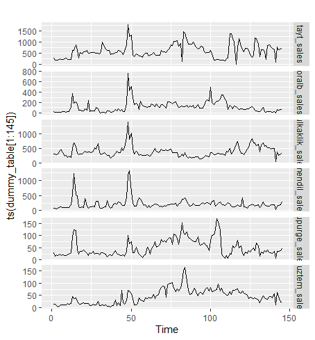

Table 2: Sales amounts after removing outliers

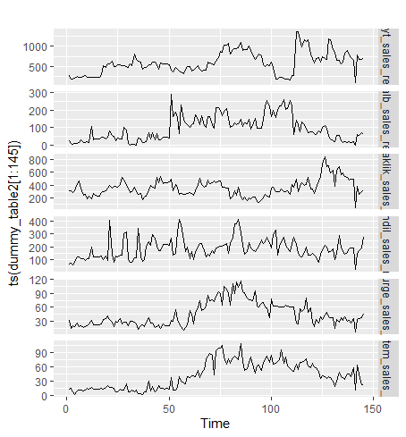

Table 3: Submitted forecast values

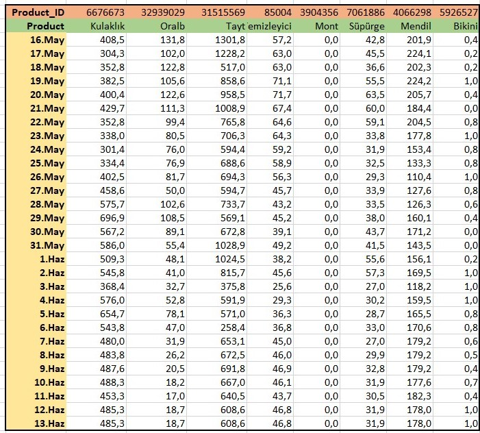

## 5) CONCLUSION AND FUTURE WORK

When the forecasts were compared with the actual results, the overall performance can be interpreted as substantial, especially when the quality of the available data is regarded. However, it is clearly seen that there is a lot of room for improvement.

Better results are achievable via the access to some other data, especially inventory levels. The stockouts played a crucial role during the project period and caused lots of errors. This problem could be solved by detailed information about the product inventories. Another type of information which would be helpful was discount events. If the future prices of products were known, more accurate forecast could be obtained. In addition, more types of data significant for sales could be provided by the company (e.g. the placement of the product on the website) or sought from other online resources such as google trends.

For further improvement, such forecasting models are applicable to many other products, which would provide the company the foresight of future profits and possible effects of any adjustments made on the products. Also such studies might be very useful in term of inventory control policies of the company.

## 6) CODE

```
##### example.r #####

install.packages("jsonlite")
install.packages("httr")
install.packages("data.table")

# install the required packages first
require(jsonlite)
require(httr)
require(data.table)

get_token <- function(username, password, url_site){

    post_body = list(username=username,password=password)
    post_url_string = paste0(url_site,'/token/')
    result = POST(post_url_string, body = post_body)

    # error handling (wrong credentials)
    if(result$status_code==400){
        print('Check your credentials')
        return(0)
    }
    else if (result$status_code==201){
        output = content(result)
        token = output$key
    }

    return(token)
}

get_data <- function(start_date='2020-03-20', token, url_site){

    post_body = list(start_date=start_date,username=username,password=password)
    post_url_string = paste0(url_site,'/dataset/')

    header = add_headers(c(Authorization=paste('Token',token,sep=' ')))
    result = GET(post_url_string, header, body = post_body)
    output = content(result)
    data = data.table::rbindlist(output)
    data[,event_date:=as.Date(event_date)]
```

[output cut: 1139 more lines]

```

###mendil###
data_mendil_ts <- ts(data_mendil_rem[,sold_count],frequency = 7)
price_for <- c(73.60,73.50)
visit_for <- as.numeric(forecast(auto.arima(ts(data_mendil_rem[,visit_count],frequency = 7)),h=2)$mean)
cat_vis_for <- as.numeric(forecast(ets(ts(data_mendil_rem[,category_visits],frequency = 7)),h=2)$mean)

reg_matrix <- matrix(c(price_for,visit_for,cat_vis_for),ncol=3)

mendil_dynam_model <- auto.arima(data_mendil_ts, xreg=as.matrix(data_mendil_rem[,c("price","visit_count","category_visits")]))
mendil_forecast <- forecast(mendil_dynam_model,xreg=reg_matrix,h=2)
#mendil_forecast

###bikini###
tail(data_bikini$sold_count,5)
```